# Initiation à `R`

DU Analyste Big Data

Dans ce document sont présentés les concepts principaux du logiciel `R` (éléments de langage, données manipulées, manipulation de données, …).

## Données et éléments de langage

### Types de données

`R` permet de manipuler différents types de données tel que :

- scalaire : une valeur de type `numeric`, `character`, `logical`, `date`
- `vector` : tableau de scalaires de même type (`numeric`, `character`, `logical`, `date`, `factor`)
- `matrix` : tableau à deux dimensions de scalaires de même type (`numeric`, `logicial` ou `character`)
- `array` : extension de `matrix` à $d$ dimensions
- `data.frame` : ensemble de lignes (entités, parfois nommées) décrites par des colonnes nommées (dites variables aussi), pouvant être de types différents - très proche de la définition d’une table dans un SGBD classique
- `list` : liste d’éléments (nommés ou non, et pas forcément de même type)

Voici un exemple avec le jeu de données `mtcars` déjà présent dans le logiciel `R` :

```r
# Type de la variable mtcars
class(mtcars)
```

```
## [1] "data.frame"
```

```r
# Dimensions
dim(mtcars)
```

```
## [1] 32 11
```

```r
nrow(mtcars)
```

```
## [1] 32
```

```r
ncol(mtcars)
```

```
## [1] 11
```

```r
# Données en elles-mêmes
mtcars
```

```
##                      mpg cyl  disp  hp drat    wt  qsec vs am gear carb
## Mazda RX4           21.0   6 160.0 110 3.90 2.620 16.46  0  1    4    4
## Mazda RX4 Wag       21.0   6 160.0 110 3.90 2.875 17.02  0  1    4    4
## Datsun 710          22.8   4 108.0  93 3.85 2.320 18.61  1  1    4    1
## Hornet 4 Drive      21.4   6 258.0 110 3.08 3.215 19.44  1  0    3    1
## Hornet Sportabout   18.7   8 360.0 175 3.15 3.440 17.02  0  0    3    2
## Valiant             18.1   6 225.0 105 2.76 3.460 20.22  1  0    3    1
## Duster 360          14.3   8 360.0 245 3.21 3.570 15.84  0  0    3    4
## Merc 240D           24.4   4 146.7  62 3.69 3.190 20.00  1  0    4    2
## Merc 230            22.8   4 140.8  95 3.92 3.150 22.90  1  0    4    2
## Merc 280            19.2   6 167.6 123 3.92 3.440 18.30  1  0    4    4
## Merc 280C           17.8   6 167.6 123 3.92 3.440 18.90  1  0    4    4
## Merc 450SE          16.4   8 275.8 180 3.07 4.070 17.40  0  0    3    3
## Merc 450SL          17.3   8 275.8 180 3.07 3.730 17.60  0  0    3    3
## Merc 450SLC         15.2   8 275.8 180 3.07 3.780 18.00  0  0    3    3
## Cadillac Fleetwood  10.4   8 472.0 205 2.93 5.250 17.98  0  0    3    4
## Lincoln Continental 10.4   8 460.0 215 3.00 5.424 17.82  0  0    3    4
## Chrysler Imperial   14.7   8 440.0 230 3.23 5.345 17.42  0  0    3    4
## Fiat 128            32.4   4  78.7  66 4.08 2.200 19.47  1  1    4    1
## Honda Civic         30.4   4  75.7  52 4.93 1.615 18.52  1  1    4    2
## Toyota Corolla      33.9   4  71.1  65 4.22 1.835 19.90  1  1    4    1
## Toyota Corona       21.5   4 120.1  97 3.70 2.465 20.01  1  0    3    1
## Dodge Challenger    15.5   8 318.0 150 2.76 3.520 16.87  0  0    3    2
## AMC Javelin         15.2   8 304.0 150 3.15 3.435 17.30  0  0    3    2
## Camaro Z28          13.3   8 350.0 245 3.73 3.840 15.41  0  0    3    4
## Pontiac Firebird    19.2   8 400.0 175 3.08 3.845 17.05  0  0    3    2
## Fiat X1-9           27.3   4  79.0  66 4.08 1.935 18.90  1  1    4    1
## Porsche 914-2       26.0   4 120.3  91 4.43 2.140 16.70  0  1    5    2
## Lotus Europa        30.4   4  95.1 113 3.77 1.513 16.90  1  1    5    2
## Ford Pantera L      15.8   8 351.0 264 4.22 3.170 14.50  0  1    5    4
## Ferrari Dino        19.7   6 145.0 175 3.62 2.770 15.50  0  1    5    6
## Maserati Bora       15.0   8 301.0 335 3.54 3.570 14.60  0  1    5    8
## Volvo 142E          21.4   4 121.0 109 4.11 2.780 18.60  1  1    4    2
```

### Typage faible

`R` est un langage de programmation à typage faible : le type de la variable est déterminée par la valeur qui lui est affectée. Ce qui veut dire qu’il est possible d’affecter une chaîne de caractères à une variable numérique. Celle-ci deviendra automatique de type chaîne de caractère. Et il n’y a pas d’opérateurs de déclaration de variables. Celle-ci est créée à sa première utilisation, dans l’environnement actuel.

#### Création d’une variable numérique

```r
a = 1
print(a)
```

```
## [1] 1
```

```r
class(a)
```

```
## [1] "numeric"
```

#### Affectation d’une chaîne de caractère à une variable numérique

```r
a = "bonjour"
print(a)
```

```
## [1] "bonjour"
```

```r
class(a)
```

```
## [1] "character"
```

#### Conclusion

**Attention** donc lors de l’écriture des programmes…

### Langage scripté

`R` est un langage scripté : il faut exécuter les commandes les unes après les autres dans la console. Mais il est possible d’écrire des scripts dans des fichiers (souvent avec l’extension `.R`), puis de les appeler via la commande `source()`

```r
source("chemin/vers/mon/fichier.R")
```

### Accès aux données

Voici quelques éléments pour accéder aux différentes valeurs présentes dans le `data.frame` `mtcars` :

```r
mtcars[1,]
```

```
##           mpg cyl disp  hp drat   wt  qsec vs am gear carb
## Mazda RX4  21   6  160 110  3.9 2.62 16.46  0  1    4    4
```

#### Valeurs de la 1ère colonne (nommée mpg) -> vector

```r
mtcars[,1]
```

```
##  [1] 21.0 21.0 22.8 21.4 18.7 18.1 14.3 24.4 22.8 19.2 17.8 16.4 17.3 15.2
## [15] 10.4 10.4 14.7 32.4 30.4 33.9 21.5 15.5 15.2 13.3 19.2 27.3 26.0 30.4
## [29] 15.8 19.7 15.0 21.4
```

```r
mtcars$mpg
```

```
##  [1] 21.0 21.0 22.8 21.4 18.7 18.1 14.3 24.4 22.8 19.2 17.8 16.4 17.3 15.2
## [15] 10.4 10.4 14.7 32.4 30.4 33.9 21.5 15.5 15.2 13.3 19.2 27.3 26.0 30.4
## [29] 15.8 19.7 15.0 21.4
```

```r
mtcars[1] # en mode data.frame
```

```
##                      mpg
## Mazda RX4           21.0
## Mazda RX4 Wag       21.0
## Datsun 710          22.8
## Hornet 4 Drive      21.4
## Hornet Sportabout   18.7
## Valiant             18.1
## Duster 360          14.3
## Merc 240D           24.4
## Merc 230            22.8
## Merc 280            19.2
## Merc 280C           17.8
## Merc 450SE          16.4
## Merc 450SL          17.3
## Merc 450SLC         15.2
## Cadillac Fleetwood  10.4
## Lincoln Continental 10.4
## Chrysler Imperial   14.7
## Fiat 128            32.4
## Honda Civic         30.4
## Toyota Corolla      33.9
## Toyota Corona       21.5
## Dodge Challenger    15.5
## AMC Javelin         15.2
## Camaro Z28          13.3
## Pontiac Firebird    19.2
## Fiat X1-9           27.3
## Porsche 914-2       26.0
## Lotus Europa        30.4
## Ford Pantera L      15.8
## Ferrari Dino        19.7
## Maserati Bora       15.0
## Volvo 142E          21.4
```

#### Valeur à la cellule (1,1)

```r
mtcars[1,1]
```

```
## [1] 21
```

```r
mtcars$mpg[1]
```

```
## [1] 21
```

#### Noms des variables

```r
names(mtcars)
```

```
##  [1] "mpg"  "cyl"  "disp" "hp"   "drat" "wt"   "qsec" "vs"   "am"   "gear"
## [11] "carb"
```

```r
colnames(mtcars)
```

```
##  [1] "mpg"  "cyl"  "disp" "hp"   "drat" "wt"   "qsec" "vs"   "am"   "gear"
## [11] "carb"
```

#### Nom des lignes

```r
rownames(mtcars)
```

```
##  [1] "Mazda RX4"           "Mazda RX4 Wag"       "Datsun 710"
##  [4] "Hornet 4 Drive"      "Hornet Sportabout"   "Valiant"
##  [7] "Duster 360"          "Merc 240D"           "Merc 230"
## [10] "Merc 280"            "Merc 280C"           "Merc 450SE"
## [13] "Merc 450SL"          "Merc 450SLC"         "Cadillac Fleetwood"
## [16] "Lincoln Continental" "Chrysler Imperial"   "Fiat 128"
## [19] "Honda Civic"         "Toyota Corolla"      "Toyota Corona"
## [22] "Dodge Challenger"    "AMC Javelin"         "Camaro Z28"
## [25] "Pontiac Firebird"    "Fiat X1-9"           "Porsche 914-2"
## [28] "Lotus Europa"        "Ford Pantera L"      "Ferrari Dino"
## [31] "Maserati Bora"       "Volvo 142E"
```

#### Descriptif de chaque variable d’un `data.frame`

```r
str(mtcars)
```

```
## 'data.frame':    32 obs. of  11 variables:
##  $ mpg : num  21 21 22.8 21.4 18.7 18.1 14.3 24.4 22.8 19.2 ...
##  $ cyl : num  6 6 4 6 8 6 8 4 4 6 ...
##  $ disp: num  160 160 108 258 360 ...
##  $ hp  : num  110 110 93 110 175 105 245 62 95 123 ...
##  $ drat: num  3.9 3.9 3.85 3.08 3.15 2.76 3.21 3.69 3.92 3.92 ...
##  $ wt  : num  2.62 2.88 2.32 3.21 3.44 ...
##  $ qsec: num  16.5 17 18.6 19.4 17 ...
##  $ vs  : num  0 0 1 1 0 1 0 1 1 1 ...
##  $ am  : num  1 1 1 0 0 0 0 0 0 0 ...
##  $ gear: num  4 4 4 3 3 3 3 4 4 4 ...
##  $ carb: num  4 4 1 1 2 1 4 2 2 4 ...
```

### Eléments de langage

Voici quelques commandes utiles

#### Création d’un vecteur et d’une matrice

```r
# vecteur de numériques
c(1, 3, 5)
```

```
## [1] 1 3 5
```

```r
# vecteur de chaînes de caractères
c("a", "b")
```

```
## [1] "a" "b"
```

```r
# vecteur de type et de taille définie
vector('logical', 5)
```

```
## [1] FALSE FALSE FALSE FALSE FALSE
```

```r
# séquence de base
1:5
```

```
## [1] 1 2 3 4 5
```

```r
# idem
seq(1, 5)
```

```
## [1] 1 2 3 4 5
```

```r
# séquence avec définition de la taille du vecteur
seq(1, 5, length = 10)
```

```
##  [1] 1.000000 1.444444 1.888889 2.333333 2.777778 3.222222 3.666667
##  [8] 4.111111 4.555556 5.000000
```

```r
# séquence avec définition du pas
seq(0, 1, by = 0.1)
```

```
##  [1] 0.0 0.1 0.2 0.3 0.4 0.5 0.6 0.7 0.8 0.9 1.0
```

```r
# répétition d'une valeur
rep(1, 5)
```

```
## [1] 1 1 1 1 1
```

```r
# répétition d'un vecteur
rep(1:2, 5)
```

```
##  [1] 1 2 1 2 1 2 1 2 1 2
```

```r
# répétition d'un vecteur, 2ème version
rep(1:2, each = 5)
```

```
##  [1] 1 1 1 1 1 2 2 2 2 2
```

```r
# matrice
matrix(1:10, 2, 5)
```

```
##      [,1] [,2] [,3] [,4] [,5]
## [1,]    1    3    5    7    9
## [2,]    2    4    6    8   10
```

```r
# création d'un vecteur et redimensionnement de celui-ci -> résultat identique à précédemment
m = 1:10
dim(m) = c(2,5)
print(m)
```

```
##      [,1] [,2] [,3] [,4] [,5]
## [1,]    1    3    5    7    9
## [2,]    2    4    6    8   10
```

#### Fonction sur les lignes ou les colonnes d’une matrice

Application d’une fonction (`sum()` ici) sur les lignes (`1`) ou sur les colonnes (`2`) d’une matrice.

```r
apply(m, 1, sum) # somme sur les lignes
```

```
## [1] 25 30
```

```r
apply(m, 2, sum) # somme sur les colonnes
```

```
## [1]  3  7 11 15 19
```

#### Fonction sur les parties d’un vecteur

Application d’une fonction (ici `mean()`) sur les groupes de valeurs d’un vecteur, groupes déterminés par les modalités d’un autre vecteur.

```r
# Consommation des voitures (Miles/(US) gallon)
mtcars$mpg
```

```
##  [1] 21.0 21.0 22.8 21.4 18.7 18.1 14.3 24.4 22.8 19.2 17.8 16.4 17.3 15.2
## [15] 10.4 10.4 14.7 32.4 30.4 33.9 21.5 15.5 15.2 13.3 19.2 27.3 26.0 30.4
## [29] 15.8 19.7 15.0 21.4
```

```r
# Transmission (0 = automatic, 1 = manual)
mtcars$am
```

```
##  [1] 1 1 1 0 0 0 0 0 0 0 0 0 0 0 0 0 0 1 1 1 0 0 0 0 0 1 1 1 1 1 1 1
```

```r
# Consommation moyenne par type de transmission
tapply(mtcars$mpg, mtcars$am, mean)
```

```
##        0        1
## 17.14737 24.39231
```

#### Combinaison des deux fonctions précédentes

En combinant les deux méthodes vu avant, on peut effectuer des opérations de type moyenne de plusieurs variables d’un jeu de données, pour chaque modalité d’une variable qualitative.

```r
# Moyenne par type de moteurs (en terme de nombre de cylindres)
# sur les variables quantitatives de mtcars
apply(mtcars[,c("mpg", "disp", "hp", "drat", "wt", "qsec")], 2, tapply, mtcars$cyl, mean)
```

```
##        mpg     disp        hp     drat       wt     qsec
## 4 26.66364 105.1364  82.63636 4.070909 2.285727 19.13727
## 6 19.74286 183.3143 122.28571 3.585714 3.117143 17.97714
## 8 15.10000 353.1000 209.21429 3.229286 3.999214 16.77214
```

## Interrogation de données

Il est fait référence ici aux principes de l’interrogation de données au sens `SQL` (et plus particulièrement la partie requêtage).

### Restriction et projection

La fonction `subset()` permet d’effectuer les deux opérations. Dans le paramètre `subset`, on indique la condition (simple ou combinée) permet de faire la restriction. Et dans le paramètre `select`, on liste les variables de la projection.

```r
subset(mtcars, subset = cyl == 4, select = c(cyl, mpg))
```

```
##                cyl  mpg
## Datsun 710       4 22.8
## Merc 240D        4 24.4
## Merc 230         4 22.8
## Fiat 128         4 32.4
## Honda Civic      4 30.4
## Toyota Corolla   4 33.9
## Toyota Corona    4 21.5
## Fiat X1-9        4 27.3
## Porsche 914-2    4 26.0
## Lotus Europa     4 30.4
## Volvo 142E       4 21.4
```

Il est aussi possible de faire ces deux opérations dans les `[]` avec un test logique et en indiquant la liste des variables à prendre.

```r
mtcars[mtcars$cyl == 4, c("cyl", "mpg")]
```

```
##                cyl  mpg
## Datsun 710       4 22.8
## Merc 240D        4 24.4
## Merc 230         4 22.8
## Fiat 128         4 32.4
## Honda Civic      4 30.4
## Toyota Corolla   4 33.9
## Toyota Corona    4 21.5
## Fiat X1-9        4 27.3
## Porsche 914-2    4 26.0
## Lotus Europa     4 30.4
## Volvo 142E       4 21.4
```

### Calcul de nouvelles variables

La fonction `tranform()` permet d’ajouter de nouvelles variables, soit résultantes d’un calcul (cf ci-dessous), soit permettant seulement un renommage d’une variable.

```r
transform(mtcars[,c("cyl", "disp")], disp_cyl = round(disp / cyl, 2))
```

```
##                     cyl  disp disp_cyl
## Mazda RX4             6 160.0    26.67
## Mazda RX4 Wag         6 160.0    26.67
## Datsun 710            4 108.0    27.00
## Hornet 4 Drive        6 258.0    43.00
## Hornet Sportabout     8 360.0    45.00
## Valiant               6 225.0    37.50
## Duster 360            8 360.0    45.00
## Merc 240D             4 146.7    36.67
## Merc 230              4 140.8    35.20
## Merc 280              6 167.6    27.93
## Merc 280C             6 167.6    27.93
## Merc 450SE            8 275.8    34.48
## Merc 450SL            8 275.8    34.48
## Merc 450SLC           8 275.8    34.48
## Cadillac Fleetwood    8 472.0    59.00
## Lincoln Continental   8 460.0    57.50
## Chrysler Imperial     8 440.0    55.00
## Fiat 128              4  78.7    19.68
## Honda Civic           4  75.7    18.93
## Toyota Corolla        4  71.1    17.77
## Toyota Corona         4 120.1    30.02
## Dodge Challenger      8 318.0    39.75
## AMC Javelin           8 304.0    38.00
## Camaro Z28            8 350.0    43.75
## Pontiac Firebird      8 400.0    50.00
## Fiat X1-9             4  79.0    19.75
## Porsche 914-2         4 120.3    30.07
## Lotus Europa          4  95.1    23.77
## Ford Pantera L        8 351.0    43.88
## Ferrari Dino          6 145.0    24.17
## Maserati Bora         8 301.0    37.62
## Volvo 142E            4 121.0    30.25
```

### Calcul d’agrégat

On peut déjà se servir de la combinaison des fonctions `apply()` et `tapply()` comme vu précédemment. Il existe aussi la fonction `aggregate()`, où l’on définit explicitement les agrégats à effectuer et les calculs à produire (un seul type de calcul par fonction néanmoins).

```r
# Agrégat simple : consommation moyenne générale
aggregate(mpg ~ 1, data = mtcars, mean)
```

```
##        mpg
## 1 20.09062
```

```r
# Agrégat classique : consommation moyenne en fonction du nombre de cylindres
aggregate(mpg ~ cyl, data = mtcars, mean)
```

```
##   cyl      mpg
## 1   4 26.66364
## 2   6 19.74286
## 3   8 15.10000
```

```r
# Agrégat à deux variables : idem en fonction en plus de la transmission
aggregate(mpg ~ cyl + am, data = mtcars, mean)
```

```
##   cyl am      mpg
## 1   4  0 22.90000
## 2   6  0 19.12500
## 3   8  0 15.05000
## 4   4  1 28.07500
## 5   6  1 20.56667
## 6   8  1 15.40000
```

```r
# Agrégat sur deux variables : idem mais pour la puissance aussi
aggregate(cbind(mpg, hp) ~ cyl + am, data = mtcars, mean)
```

```
##   cyl am      mpg        hp
## 1   4  0 22.90000  84.66667
## 2   6  0 19.12500 115.25000
## 3   8  0 15.05000 194.16667
## 4   4  1 28.07500  81.87500
## 5   6  1 20.56667 131.66667
## 6   8  1 15.40000 299.50000
```

### Jointures

Pour effectuer tout type de jointure, nous utilisons la fonction `merge()`, dans laquelle on indique les deux tables (correspondant à `x` et `y` respectivement). Les paramètres booléens `all`, `all.x` et `all.y` permettent de dire, s’ils sont à la valeur `TRUE`, quelle type de jointure externe on désire (resp. `FULL`, `LEFT` et `RIGHT`). Par défaut, la jointure se faire sur l’égalité des variables de mêmes noms entre les deux `data.frame`. On peut spécifier les variables à utiliser dans les paramètres `by`, `by.x` et `by.y`.

```r
moteur = data.frame(cyl = c(4, 6, 8, 12), def = c("petit moteur", "moteur moyen", "gros moteur", "encore plus gros moteur"))
print(moteur)
```

```
##   cyl                     def
## 1   4            petit moteur
## 2   6            moteur moyen
## 3   8             gros moteur
## 4  12 encore plus gros moteur
```

```r
merge(
  moteur,
  aggregate(mpg ~ cyl, data = mtcars, mean),
  all = TRUE
)
```

```
##   cyl                     def      mpg
## 1   4            petit moteur 26.66364
## 2   6            moteur moyen 19.74286
## 3   8             gros moteur 15.10000
## 4  12 encore plus gros moteur       NA
```

### Sinon, du `SQL` sur les `data.frame`

La librairie `sqldf` permet d’exécuter des requêtes `SQL` directement sur les `data.frame` présents dans `R`. Voici un exemple simple :

```r
library(sqldf)
sqldf("
SELECT cyl, AVG(mpg), AVG(disp), AVG(hp), AVG(drat), AVG(wt), AVG(qsec)
  FROM mtcars
  GROUP BY cyl;
      ")
```

```
##   cyl AVG(mpg) AVG(disp)   AVG(hp) AVG(drat)  AVG(wt) AVG(qsec)
## 1   4 26.66364  105.1364  82.63636  4.070909 2.285727  19.13727
## 2   6 19.74286  183.3143 122.28571  3.585714 3.117143  17.97714
## 3   8 15.10000  353.1000 209.21429  3.229286 3.999214  16.77214
```

## Quelques statistiques descriptives

La fonction `summary()` calcule des statistiques basiques sur un vecteur, celles-ci étant dépendantes du type du vecteur. Si elle est appliquée sur un `data.frame`, elle s’applique sur chaque variable.

```r
summary(mtcars)
```

```
##       mpg             cyl             disp             hp
##  Min.   :10.40   Min.   :4.000   Min.   : 71.1   Min.   : 52.0
##  1st Qu.:15.43   1st Qu.:4.000   1st Qu.:120.8   1st Qu.: 96.5
##  Median :19.20   Median :6.000   Median :196.3   Median :123.0
##  Mean   :20.09   Mean   :6.188   Mean   :230.7   Mean   :146.7
##  3rd Qu.:22.80   3rd Qu.:8.000   3rd Qu.:326.0   3rd Qu.:180.0
##  Max.   :33.90   Max.   :8.000   Max.   :472.0   Max.   :335.0
##       drat             wt             qsec             vs
##  Min.   :2.760   Min.   :1.513   Min.   :14.50   Min.   :0.0000
##  1st Qu.:3.080   1st Qu.:2.581   1st Qu.:16.89   1st Qu.:0.0000
##  Median :3.695   Median :3.325   Median :17.71   Median :0.0000
##  Mean   :3.597   Mean   :3.217   Mean   :17.85   Mean   :0.4375
##  3rd Qu.:3.920   3rd Qu.:3.610   3rd Qu.:18.90   3rd Qu.:1.0000
##  Max.   :4.930   Max.   :5.424   Max.   :22.90   Max.   :1.0000
##        am              gear            carb
##  Min.   :0.0000   Min.   :3.000   Min.   :1.000
##  1st Qu.:0.0000   1st Qu.:3.000   1st Qu.:2.000
##  Median :0.0000   Median :4.000   Median :2.000
##  Mean   :0.4062   Mean   :3.688   Mean   :2.812
##  3rd Qu.:1.0000   3rd Qu.:4.000   3rd Qu.:4.000
##  Max.   :1.0000   Max.   :5.000   Max.   :8.000
```

```r
summary(mtcars$mpg)
```

```
##    Min. 1st Qu.  Median    Mean 3rd Qu.    Max.
##   10.40   15.43   19.20   20.09   22.80   33.90
```

```r
summary(mtcars$cyl)
```

```
##    Min. 1st Qu.  Median    Mean 3rd Qu.    Max.
##   4.000   4.000   6.000   6.188   8.000   8.000
```

```r
summary(as.factor(mtcars$cyl))
```

```
##  4  6  8
## 11  7 14
```

### Univarié

On peut accéder aux fonctions de calculs des statistiques descriptives directement. Pour les variables quantitatives, nous allons utiliser comme exemple `mpg` qui représente la consommation.

```r
mean(mtcars$mpg)
```

```
## [1] 20.09062
```

```r
sum(mtcars$mpg)
```

```
## [1] 642.9
```

```r
var(mtcars$mpg)
```

```
## [1] 36.3241
```

```r
sd(mtcars$mpg)
```

```
## [1] 6.026948
```

```r
min(mtcars$mpg)
```

```
## [1] 10.4
```

```r
max(mtcars$mpg)
```

```
## [1] 33.9
```

```r
range(mtcars$mpg)
```

```
## [1] 10.4 33.9
```

```r
median(mtcars$mpg)
```

```
## [1] 19.2
```

```r
quantile(mtcars$mpg)
```

```
##     0%    25%    50%    75%   100%
## 10.400 15.425 19.200 22.800 33.900
```

```r
quantile(mtcars$mpg, probs = 0.99)
```

```
##    99%
## 33.435
```

```r
quantile(mtcars$mpg, probs = c(0.01, 0.1, 0.9, 0.99))
```

```
##     1%    10%    90%    99%
## 10.400 14.340 30.090 33.435
```

Il existe tout un ensemble de fonctions graphiques, dont voici quelques exemples.

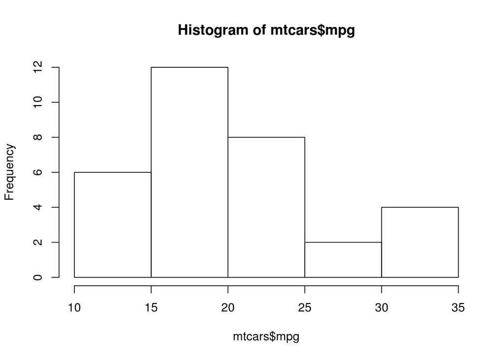

```r
hist(mtcars$mpg)
```

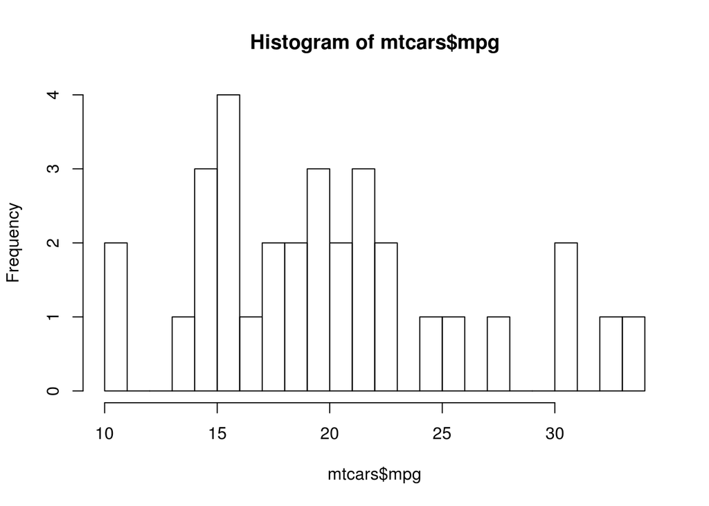

```r
hist(mtcars$mpg, breaks = 20)
```

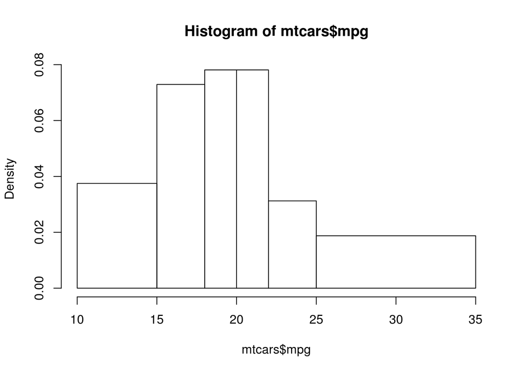

```r
hist(mtcars$mpg, breaks = c(10, 15, 18, 20, 22, 25, 35))
```

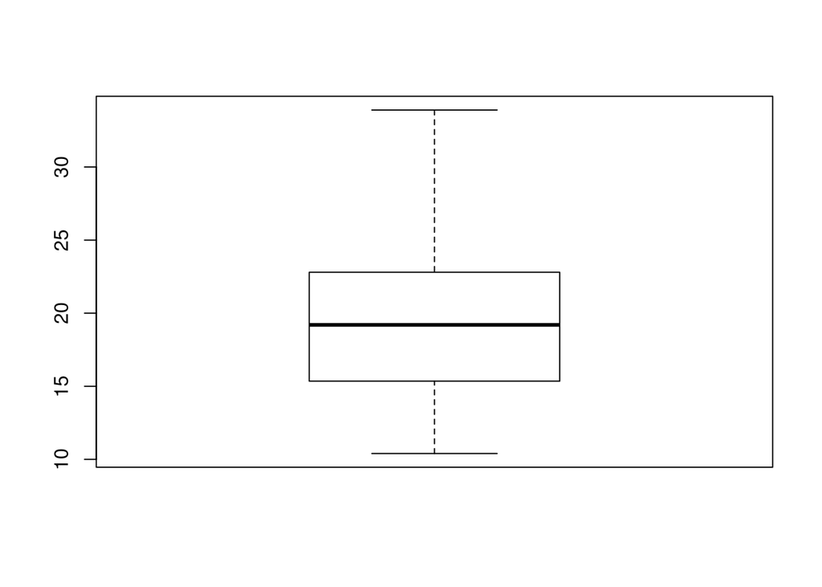

```r
boxplot(mtcars$mpg)
```

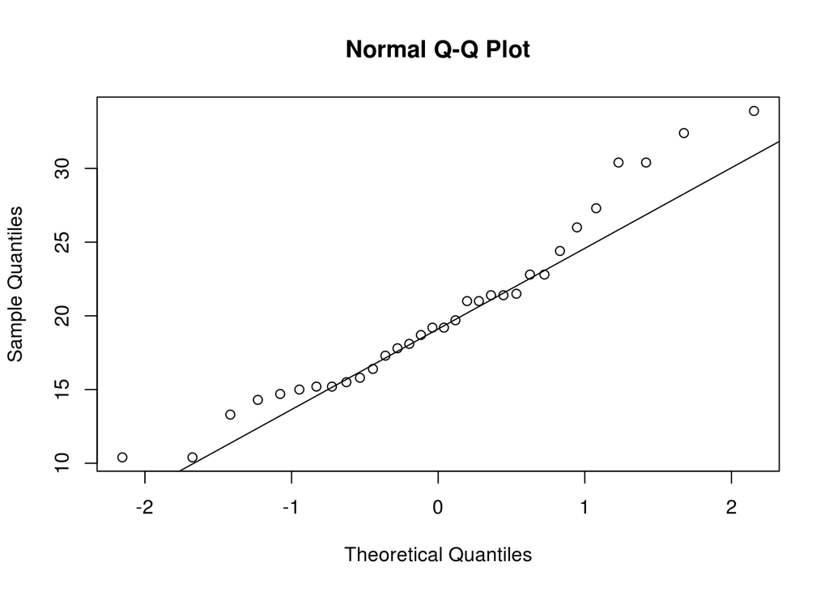

```r
qqnorm(mtcars$mpg)
qqline(mtcars$mpg)
```

Pour les variables qualitatives, nous allons utiliser la variable `cyl` qui représente le nombre de cylindre. Celle-ci étant codée numériquement, toutes les fonctions vues précédemment pour s’appliquer (mais n’avoir aucun sens).

```r
table(mtcars$cyl)
```

```
##
##  4  6  8
## 11  7 14
```

```r
prop.table(table(mtcars$cyl))
```

```
##
##       4       6       8
## 0.34375 0.21875 0.43750
```

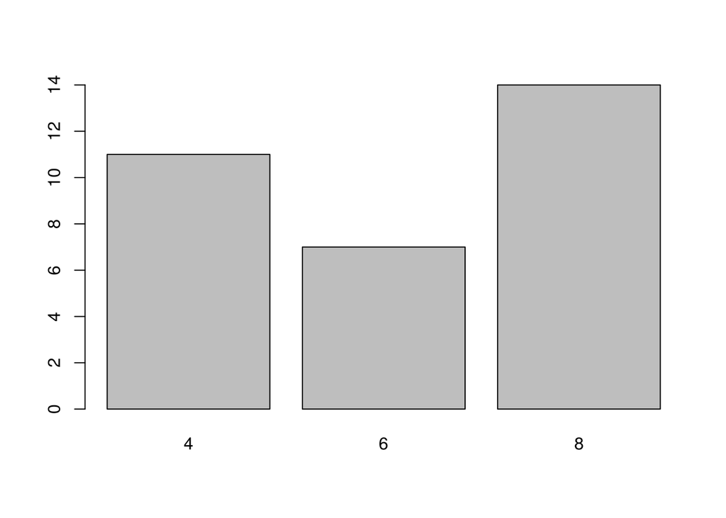

```r
barplot(table(mtcars$cyl))
```

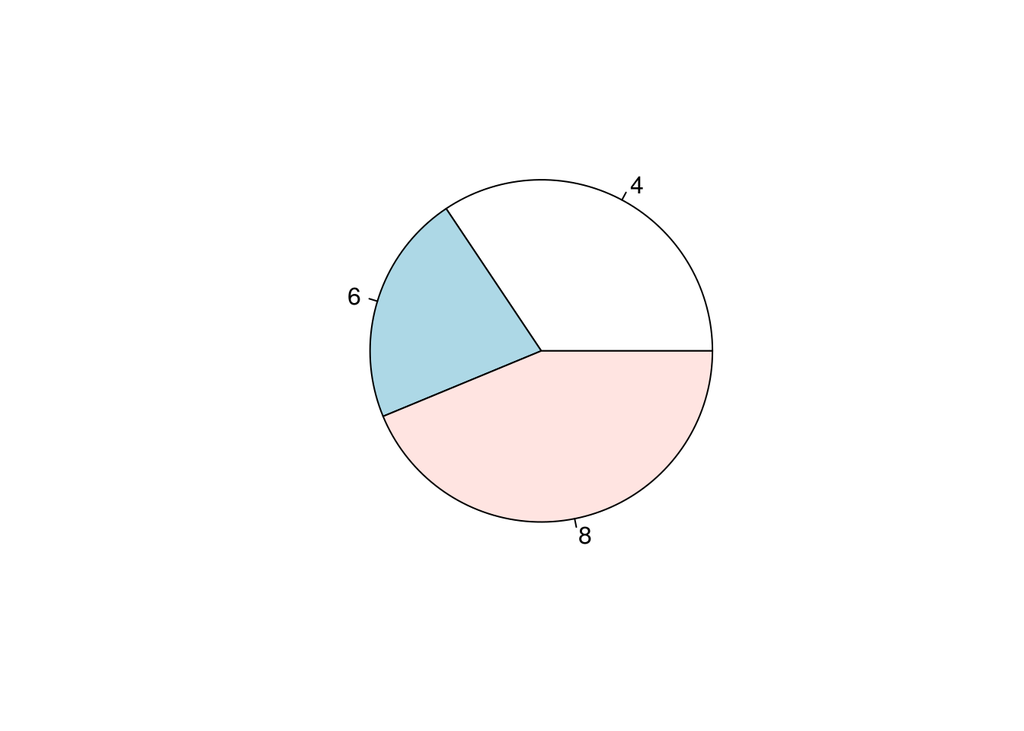

```r
pie(table(mtcars$cyl))
```

### Bivarié

#### Quanti - Quanti

Dans ce cadre, on peut bien évidemment calculer les statistiques usuelles (covariance, corrélation) et le nuage de points.

```r
cov(mtcars$mpg, mtcars$wt)
```

```
## [1] -5.116685
```

```r
cor(mtcars$mpg, mtcars$wt)
```

```
## [1] -0.8676594
```

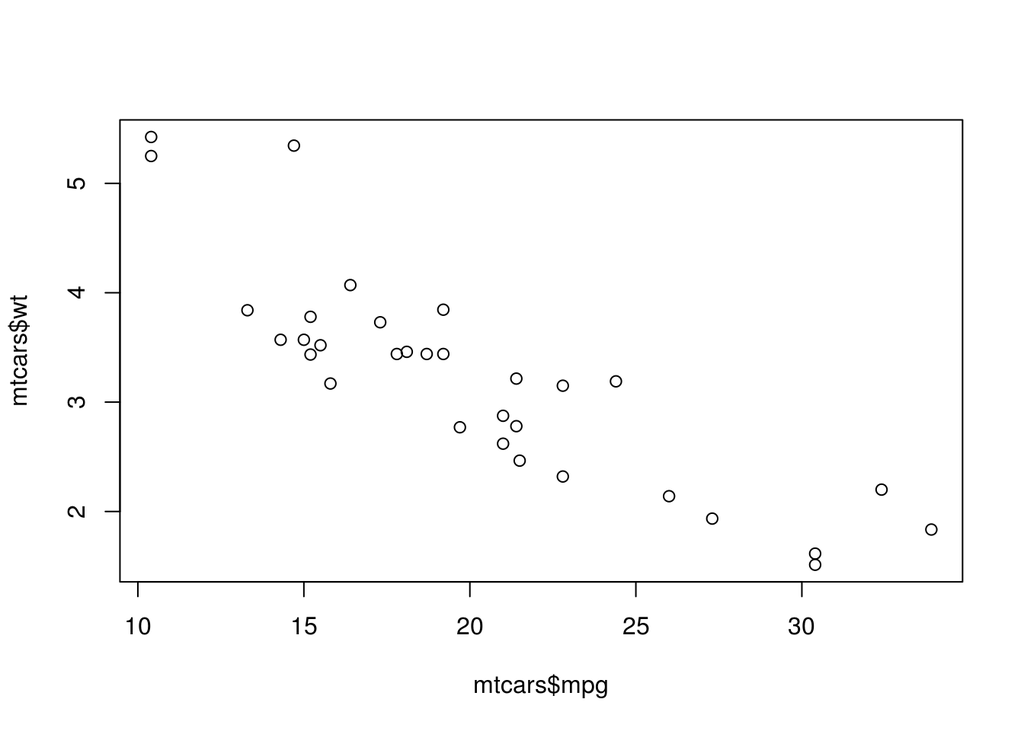

```r
plot(mtcars$mpg, mtcars$wt)
```

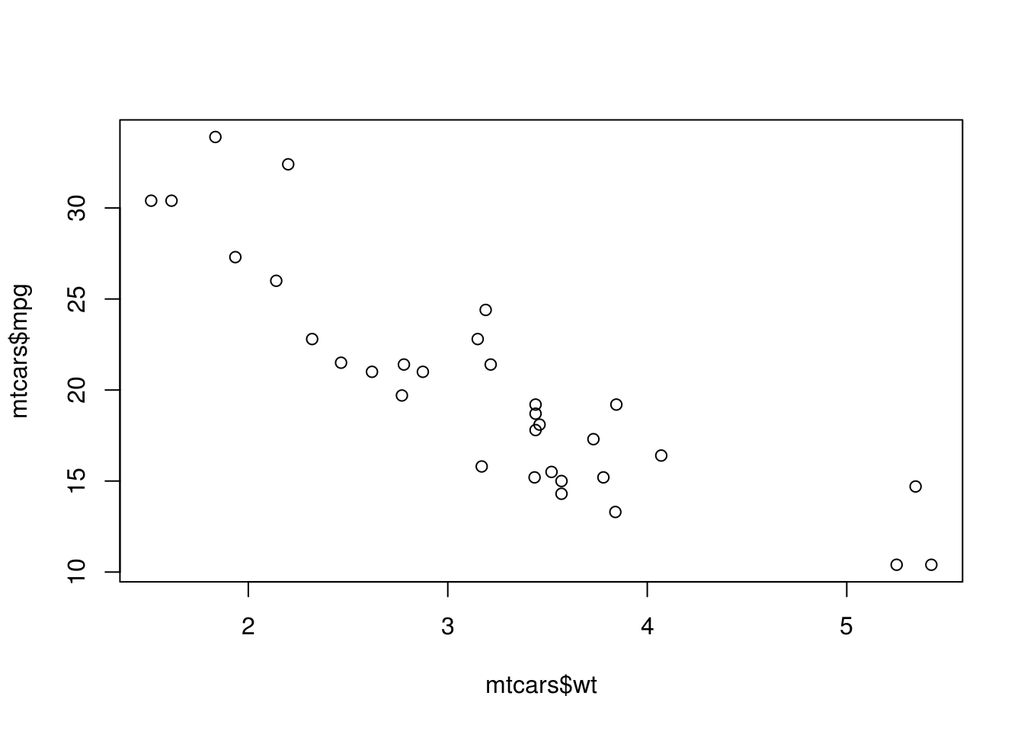

```r
plot(mtcars$mpg ~ mtcars$wt)
```

On peut aller plus loin en faisant un modéle linéaire simple.

```r
m = lm(mpg ~ wt, data = mtcars)
m
```

```
##
## Call:
## lm(formula = mpg ~ wt, data = mtcars)
##
## Coefficients:
## (Intercept)           wt
##      37.285       -5.344
```

```r
summary(m)
```

```
##
## Call:
## lm(formula = mpg ~ wt, data = mtcars)
##
## Residuals:
##     Min      1Q  Median      3Q     Max
## -4.5432 -2.3647 -0.1252  1.4096  6.8727
##
## Coefficients:
##             Estimate Std. Error t value Pr(>|t|)
## (Intercept)  37.2851     1.8776  19.858  < 2e-16 ***
## wt           -5.3445     0.5591  -9.559 1.29e-10 ***
## ---
## Signif. codes:  0 '***' 0.001 '**' 0.01 '*' 0.05 '.' 0.1 ' ' 1
##
## Residual standard error: 3.046 on 30 degrees of freedom
## Multiple R-squared:  0.7528, Adjusted R-squared:  0.7446
## F-statistic: 91.38 on 1 and 30 DF,  p-value: 1.294e-10
```

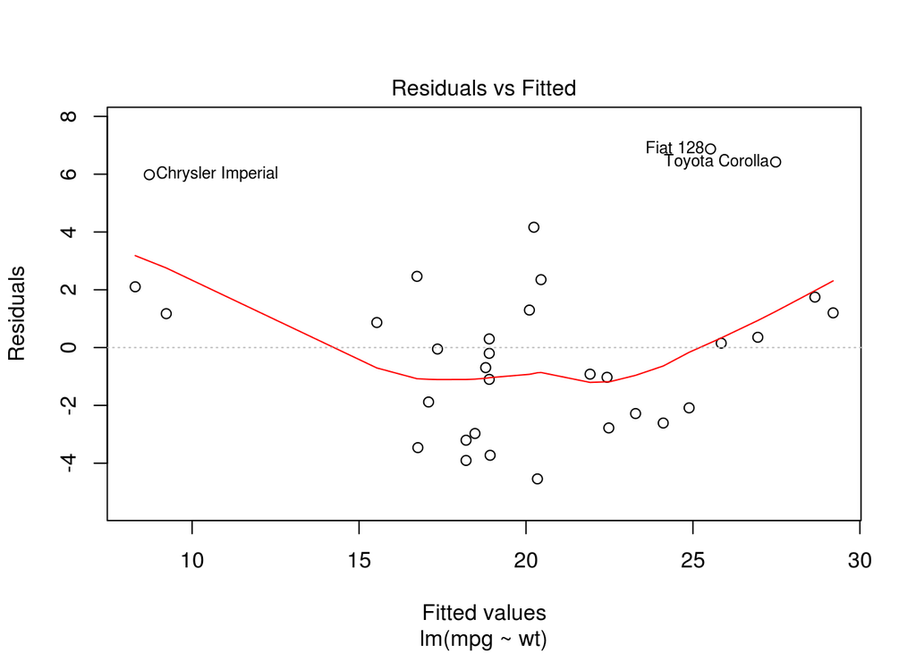

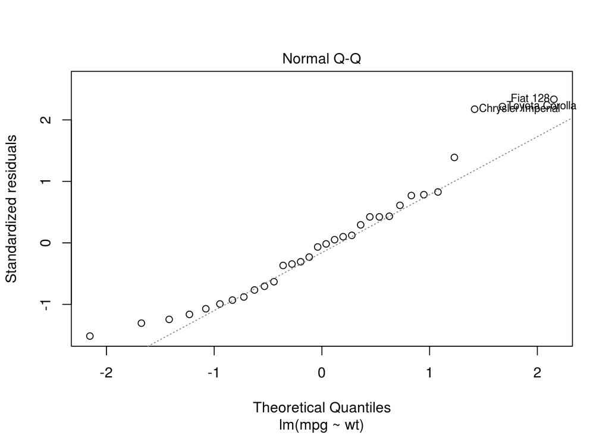

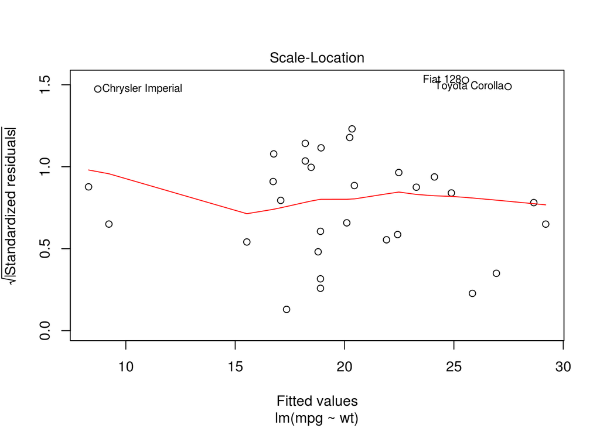

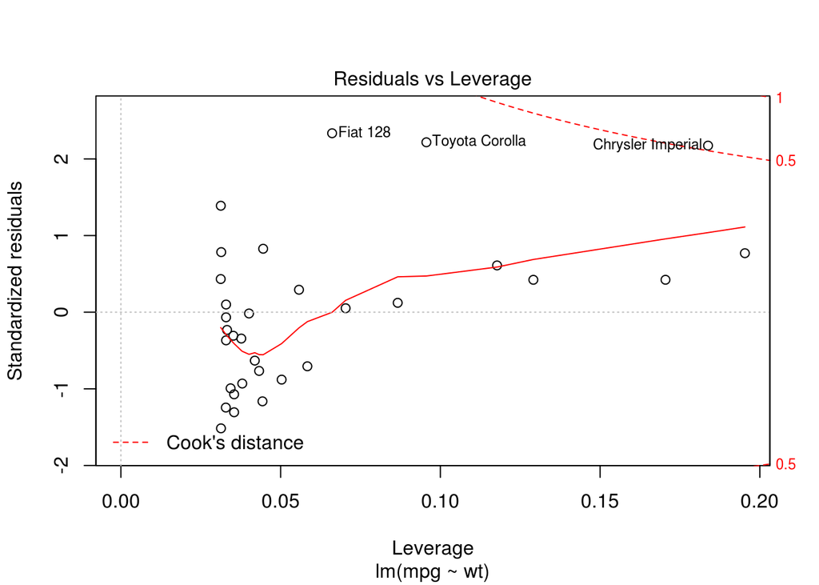

```r
plot(m)
```

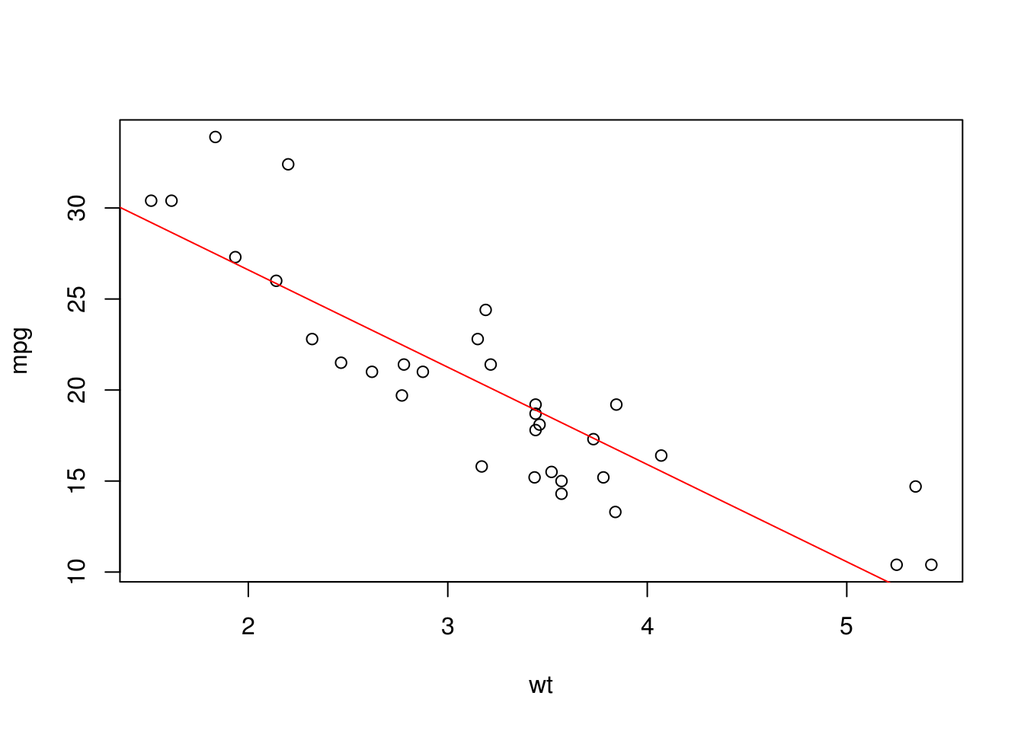

```r
plot(mpg ~ wt, data = mtcars)
abline(m, col = "red")
```

#### Quali - Quali

Ici, on calcule bien évidemment la table de contingence, mais aussi les fréquences totales et marginales (en lignes et en colonnes).

```r
t <- table(mtcars$cyl, mtcars$am)
print(t)
```

```
##
##      0  1
##   4  3  8
##   6  4  3
##   8 12  2
```

```r
prop.table(t)
```

```
##
##           0       1
##   4 0.09375 0.25000
##   6 0.12500 0.09375
##   8 0.37500 0.06250
```

```r
prop.table(t, margin = 1)
```

```
##
##             0         1
##   4 0.2727273 0.7272727
##   6 0.5714286 0.4285714
##   8 0.8571429 0.1428571
```

```r
prop.table(t, margin = 2)
```

```
##
##             0         1
##   4 0.1578947 0.6153846
##   6 0.2105263 0.2307692
##   8 0.6315789 0.1538462
```

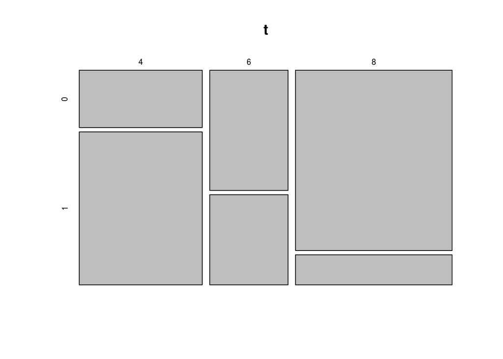

```r
mosaicplot(t)
```

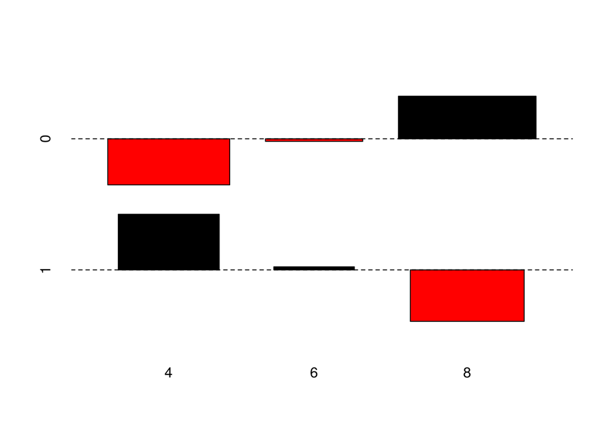

```r
assocplot(t)
```

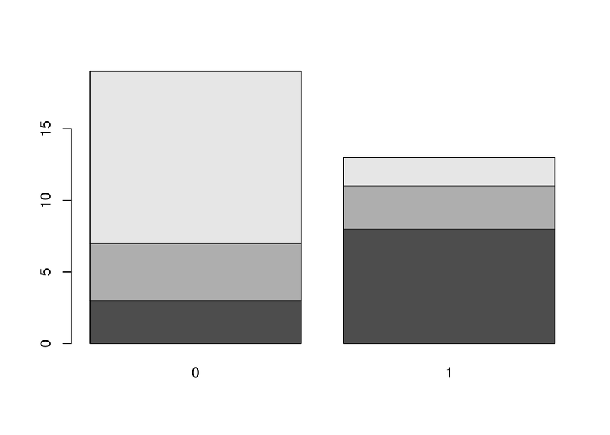

```r
barplot(t)
```

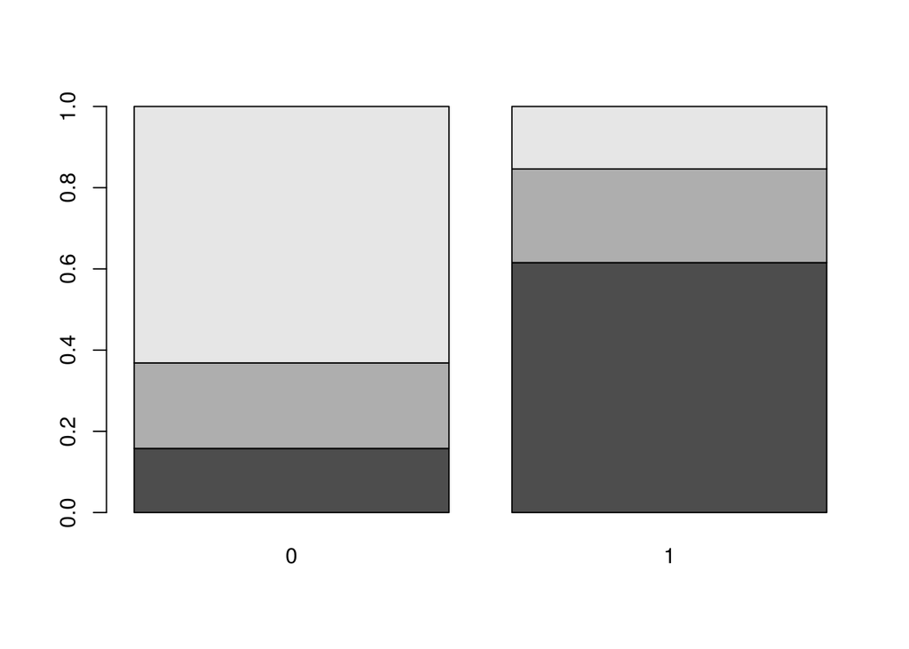

```r
barplot(prop.table(t, margin = 2))
```

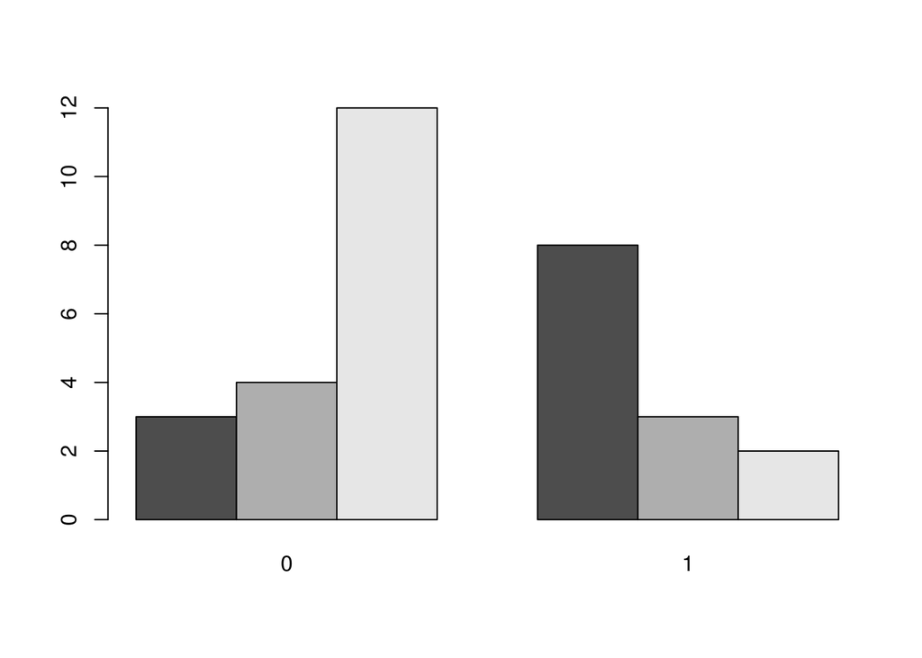

```r
barplot(t, beside = T)
```

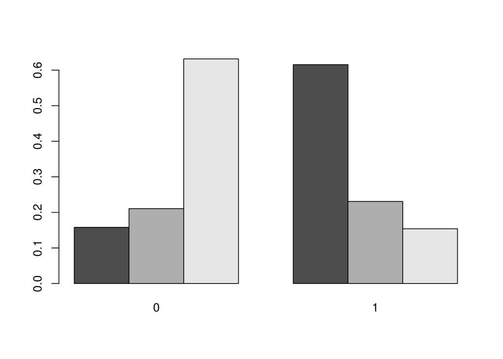

```r
barplot(prop.table(t, margin = 2), beside = T)
```

#### Quali - Quanti

En plus d’obtenir les statistiques par modalité de la variable qualitative, on peut représenter les boîtes à moustaches.

```r
tapply(mtcars$mpg, mtcars$cyl, mean)
```

```
##        4        6        8
## 26.66364 19.74286 15.10000
```

```r
tapply(mtcars$mpg, mtcars$cyl, summary)
```

```
## $`4`
##    Min. 1st Qu.  Median    Mean 3rd Qu.    Max.
##   21.40   22.80   26.00   26.66   30.40   33.90
##
## $`6`
##    Min. 1st Qu.  Median    Mean 3rd Qu.    Max.
##   17.80   18.65   19.70   19.74   21.00   21.40
##
## $`8`
##    Min. 1st Qu.  Median    Mean 3rd Qu.    Max.
##   10.40   14.40   15.20   15.10   16.25   19.20
```

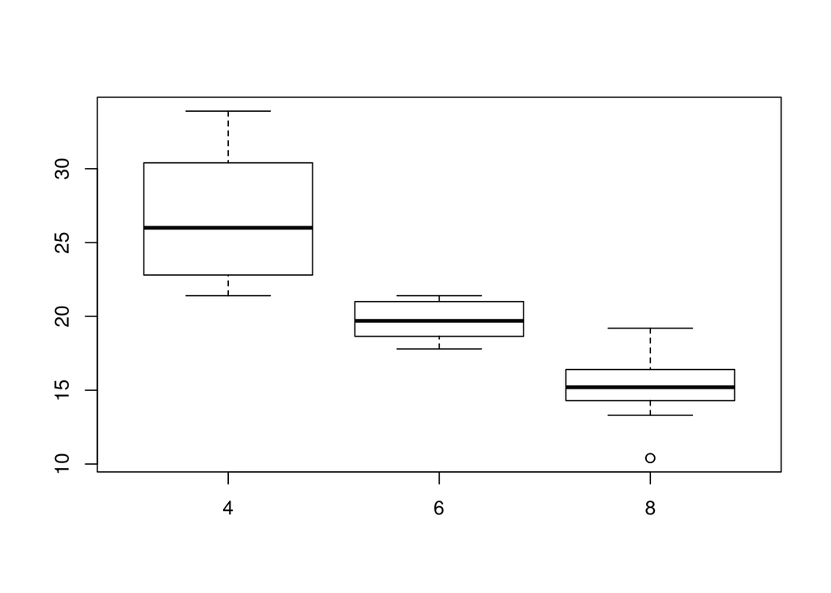

```r
boxplot(mpg ~ cyl, data = mtcars)
```

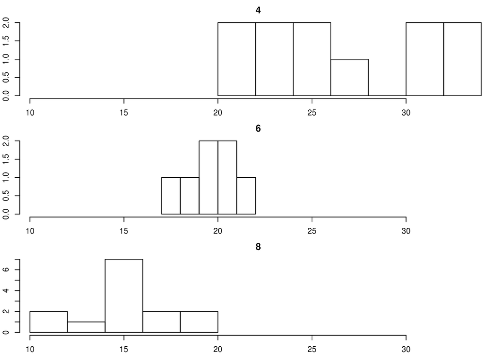

```r
par(mfrow = c(3, 1), mar = c(2, 2, 2, 0) + 0.1)
for (c in c(4, 6, 8)) {
  hist(mtcars$mpg[mtcars$cyl == c], xlim = range(mtcars$mpg), main = c)
}
```

## Manipulation de listes

Il existe un type `list` en `R`, permettant de représenter un ensemble d’objets complexes, éventuellement avec des schémas différents et pouvant contenir eux-mêmes toutes sortes d’objets (`vector`, `matrix`, `data.frame`, `list`, …).

```r
l = list(a = "chaîne",
         b = 12,
         c = 1:10,
         d = head(mtcars),
         e = list(x = 1:10, y = log(1:10)))
length(l)
```

```
## [1] 5
```

```r
names(l)
```

```
## [1] "a" "b" "c" "d" "e"
```

```r
l[1]
```

```
## $a
## [1] "chaîne"
```

```r
l[[1]]
```

```
## [1] "chaîne"
```

```r
l$a
```

```
## [1] "chaîne"
```

```r
l[1:2]
```

```
## $a
## [1] "chaîne"
##
## $b
## [1] 12
```

```r
l[c("a", "c")]
```

```
## $a
## [1] "chaîne"
##
## $c
##  [1]  1  2  3  4  5  6  7  8  9 10
```

```r
l[sapply(l, length) == 1]
```

```
## $a
## [1] "chaîne"
##
## $b
## [1] 12
```

### `lapply` et autres

La fonction `lapply()` permet d’exécuter une fonction (passée en deuxième paramètre) à chaque élément d’une liste (passée en premier paramètre), ou un vecteur. Il existe aussi les fonctions `sapply()` et `vapply()`, qui sont similaires mais qui cherchent à simplifier le résultat (la deuxième permet de spécifier le nom des retours de la fonctions, si ceux-ci sont multiples).

```r
lapply(l, class)
```

```
## $a
## [1] "character"
##
## $b
## [1] "numeric"
##
## $c
## [1] "integer"
##
## $d
## [1] "data.frame"
##
## $e
## [1] "list"
```

```r
sapply(l, class)
```

```
##            a            b            c            d            e
##  "character"    "numeric"    "integer" "data.frame"       "list"
```

### Fonction particulière

On a parfois (voire souvent) besoin d’utiliser une fonction spécifique dans les fonctions comme `lapply()`. On peut soit la définir avant et l’utiliser comme une autre.

```r
infoElement <- function(e) {
    return(c(classe = class(e), longueur = length(e)))
}
lapply(l, infoElement)
```

```
## $a
##      classe    longueur
## "character"         "1"
##
## $b
##    classe  longueur
## "numeric"       "1"
##
## $c
##    classe  longueur
## "integer"      "10"
##
## $d
##       classe     longueur
## "data.frame"         "11"
##
## $e
##   classe longueur
##   "list"      "2"
```

```r
sapply(l, infoElement)
```

```
##          a           b         c         d            e
## classe   "character" "numeric" "integer" "data.frame" "list"
## longueur "1"         "1"       "10"      "11"         "2"
```

```r
vapply(l, infoElement, c(CLASSE = "", LONG = ""))
```

```
##        a           b         c         d            e
## CLASSE "character" "numeric" "integer" "data.frame" "list"
## LONG   "1"         "1"       "10"      "11"         "2"
```

### Fonction anonyme

Mais puisqu’on ne l’utilise généralement que dans cette fonction, il est possible de la déclarer directement dans la fonction `lapply()`. On parle alors de *fonction anonyme* (comme en *JavaScript* par exemple).

```r
sapply(l, function(e) {
    return(c(classe = class(e), longueur = length(e)))
})
```

```
##          a           b         c         d            e
## classe   "character" "numeric" "integer" "data.frame" "list"
## longueur "1"         "1"       "10"      "11"         "2"
```

### Fonctionnement *invisible*

On a parfois besoin d’appliquer une fonction qui ne retourne rien à une liste, par exemple pour afficher l’élément ou une partie de celui-ci. Dans l’exemple ci-dessous, on remarque que le code affiche bien chaque élément, mais renvoie aussi une liste contenant les éléments (qui est donc identique à la liste passée en paramètre). Ce comportement est dû au fait que la fonction ne renvoie pas de résultat.

```r
lapply(l, function (e) { print(e); })
```

```
## [1] "chaîne"
## [1] 12
##  [1]  1  2  3  4  5  6  7  8  9 10
##                    mpg cyl disp  hp drat    wt  qsec vs am gear carb
## Mazda RX4         21.0   6  160 110 3.90 2.620 16.46  0  1    4    4
## Mazda RX4 Wag     21.0   6  160 110 3.90 2.875 17.02  0  1    4    4
## Datsun 710        22.8   4  108  93 3.85 2.320 18.61  1  1    4    1
## Hornet 4 Drive    21.4   6  258 110 3.08 3.215 19.44  1  0    3    1
## Hornet Sportabout 18.7   8  360 175 3.15 3.440 17.02  0  0    3    2
## Valiant           18.1   6  225 105 2.76 3.460 20.22  1  0    3    1
## $x
##  [1]  1  2  3  4  5  6  7  8  9 10
##
## $y
##  [1] 0.0000000 0.6931472 1.0986123 1.3862944 1.6094379 1.7917595 1.9459101
##  [8] 2.0794415 2.1972246 2.3025851
```

```
## $a
## [1] "chaîne"
##
## $b
## [1] 12
##
## $c
##  [1]  1  2  3  4  5  6  7  8  9 10
##
## $d
##                    mpg cyl disp  hp drat    wt  qsec vs am gear carb
## Mazda RX4         21.0   6  160 110 3.90 2.620 16.46  0  1    4    4
## Mazda RX4 Wag     21.0   6  160 110 3.90 2.875 17.02  0  1    4    4
## Datsun 710        22.8   4  108  93 3.85 2.320 18.61  1  1    4    1
## Hornet 4 Drive    21.4   6  258 110 3.08 3.215 19.44  1  0    3    1
## Hornet Sportabout 18.7   8  360 175 3.15 3.440 17.02  0  0    3    2
## Valiant           18.1   6  225 105 2.76 3.460 20.22  1  0    3    1
##
## $e
## $e$x
##  [1]  1  2  3  4  5  6  7  8  9 10
##
## $e$y
##  [1] 0.0000000 0.6931472 1.0986123 1.3862944 1.6094379 1.7917595 1.9459101
##  [8] 2.0794415 2.1972246 2.3025851
```

Dans ce type de cas, si on veut éviter ce comportement, on peut utiliser la fonction `invisibile()`. Ceci va rendre invisible l’exécution du code et on ne verra donc pas la liste retournée par `lapply()`.

```r
invisible(lapply(l, function (e) { print(e); }))
```

```
## [1] "chaîne"
## [1] 12
##  [1]  1  2  3  4  5  6  7  8  9 10
##                    mpg cyl disp  hp drat    wt  qsec vs am gear carb
## Mazda RX4         21.0   6  160 110 3.90 2.620 16.46  0  1    4    4
## Mazda RX4 Wag     21.0   6  160 110 3.90 2.875 17.02  0  1    4    4
## Datsun 710        22.8   4  108  93 3.85 2.320 18.61  1  1    4    1
## Hornet 4 Drive    21.4   6  258 110 3.08 3.215 19.44  1  0    3    1
## Hornet Sportabout 18.7   8  360 175 3.15 3.440 17.02  0  0    3    2
## Valiant           18.1   6  225 105 2.76 3.460 20.22  1  0    3    1
## $x
##  [1]  1  2  3  4  5  6  7  8  9 10
##
## $y
##  [1] 0.0000000 0.6931472 1.0986123 1.3862944 1.6094379 1.7917595 1.9459101
##  [8] 2.0794415 2.1972246 2.3025851
```

### Fonctions autres

#### Recherche

Il est possible de faire une recherche dans une liste (ou un vecteur) avec les fonctions `Find()` et `Position()`. Celles-ci renvoient le premier élément trouvé (ou le dernier car il est possible de partir de la droite). La fonction passée en premier paramètre doit renvoyer les valeurs `TRUE` ou `FALSE`.

On cherche par exemple ici le premier (ou dernier) élément de type `vector` dans la liste précédemment créée.

```r
Find(is.vector, l)
```

```
## [1] "chaîne"
```

```r
Find(is.vector, l, right = TRUE)
```

```
## $x
##  [1]  1  2  3  4  5  6  7  8  9 10
##
## $y
##  [1] 0.0000000 0.6931472 1.0986123 1.3862944 1.6094379 1.7917595 1.9459101
##  [8] 2.0794415 2.1972246 2.3025851
```

```r
Position(is.vector, l)
```

```
## [1] 1
```

```r
Position(is.vector, l, right = TRUE)
```

```
## [1] 5
```

#### Filtre

Pour récupérer tous les éléments d’une liste respectant une condition (grâce à la fonction passée en paramètre donc), on dispose de la fonction `Filter()`. Nous récupérons ici tous les éléments de la liste qui sont de type `vector`.

```r
Filter(is.vector, l)
```

```
## $a
## [1] "chaîne"
##
## $b
## [1] 12
##
## $c
##  [1]  1  2  3  4  5  6  7  8  9 10
##
## $e
## $e$x
##  [1]  1  2  3  4  5  6  7  8  9 10
##
## $e$y
##  [1] 0.0000000 0.6931472 1.0986123 1.3862944 1.6094379 1.7917595 1.9459101
##  [8] 2.0794415 2.1972246 2.3025851
```

#### Réduction

On peut opérer une opération de réduction d’une liste à l’aide d’une fonction binaire (à deux paramètres donc).

```r
Reduce(function(a, b) return(a + b), 1:5, 0)
```

```
## [1] 15
```

Pour fonctionner correctement, la fonction doit retourner un objet utilisable dans la fonction. Dans l’exemple ci-dessous, nous transformons `mtcars` en une liste de 32 éléments, chacune étant une liste nommée des caractéristiques de la voiture (avec en plus le nom de celle-ci).

```r
mt = lapply(1:nrow(mtcars), function(i) {
        return(c(nom = rownames(mtcars)[i], as.list(mtcars[i,])))
    })
unlist(mt[[1]]) # unlist() utilisé pour améliorer l'affichage
```

```
##         nom         mpg         cyl        disp          hp        drat
## "Mazda RX4"        "21"         "6"       "160"       "110"       "3.9"
##          wt        qsec          vs          am        gear        carb
##      "2.62"     "16.46"         "0"         "1"         "4"         "4"
```

Imaginons qu’on souhaite faire la somme des consommations, il nous faut créer une liste initiale avec la valeur `0` pour l’élément `mpg`. Ensuite, on additionne les deux valeurs qu’on stocke dans `a` (qui aura pour première valeur `init`) et on retourne celle-ci.

```r
init = list(mpg = 0)
Reduce(function(a, b) { a$mpg = a$mpg + b$mpg; return(a)}, mt, init)
```

```
## $mpg
## [1] 642.9
```

## A faire

A partir des données présentes dans le fichier `world-liste.RData`, répondre aux questions suivantes. Ces données concernent les pays dans le monde (à la fin du siècle dernier), et sont représentées sous forme de liste dans l’objet `Country.liste`.

1. Donner le nombre de pays représentés
2. Trouver les informations concernant la `France`
3. Lister les pays du continent `Antarctica`
4. Calculer la population mondiale
5. Afficher quelques informations pour chaque pays (un pays par ligne) :
   - si l’année d’indépendance (`IndepYear`) est `NA`, alors on affichera

   `pays (continent)`
   - sinon, on affichera :

   `pays (continent - indépendance en XXXX)`
6. Créer une nouvelle liste avec le de ratio de la population des villes du pays (voir `City`) sur la population du pays (`Population`)
7. Identifier (donner leur nom) les pays ayant un ratio supérieur à `1` avec la nouvelle liste créée